# Structural Divergence Analysis

Maria Laura Marcos, Julian Echave

# Introduction

We study the evolutionary divergence of proteins using the LF-ENM and comparing simulated mutants with experimental data. For the core we considered sites with no gaps in the whole multiple alignment.

We studied the snakesToxin family. We used the ENM ANM with R0 = 10 to generate mutants. We used as reference for the ENM the protein with pdb code 1ntx. We simulated 10 mutants of this reference for each protein of the family. The snakesToxin family is of the type small and consists of the following proteins:

```
 [1] "2crt"  "2cdx"  "1cdta" "1tgxa" "1kxia" "1tfs"  "1drs"  "1txb"
 [9] "2ctx"  "1ntn"  "1lsi"  "2abxa" "2nbta" "1nean" "1nor"  "1cod"
[17] "1nxb"  "1fas"  "1kbt"
```

# Structural divergence along sites

Here we study how structural divergence varies from site to site. We compare simulated data with empirical data.

### Mean z.RSD vs site

To measure structural divergence we use z.RSD profiles, which are the best for most families. The following plot compares the mean z.RSD profiles, including standard errors (with .999 confidence level for the mean)

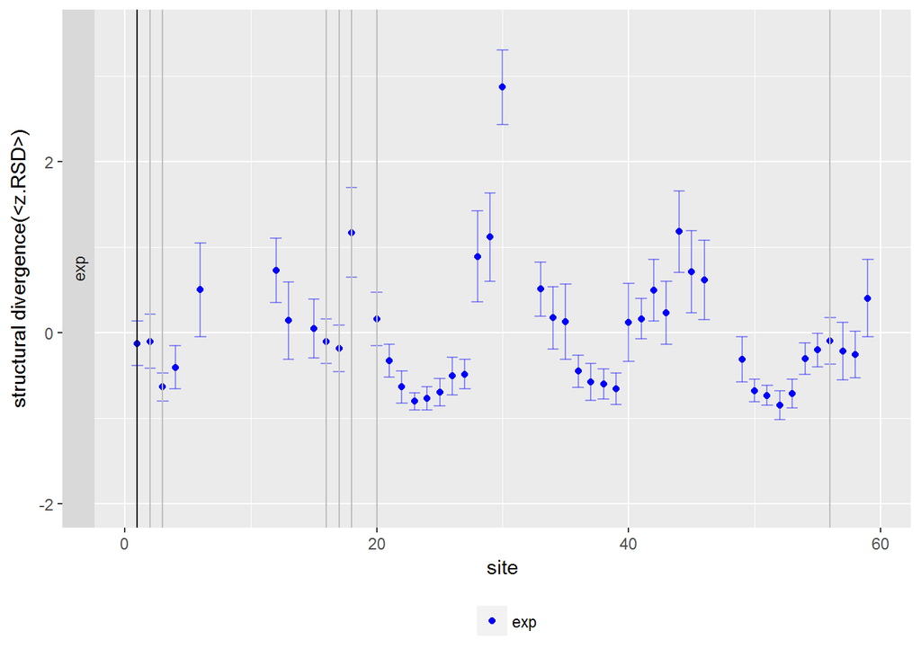

Black lines are the active sites and grey lines are their contacts

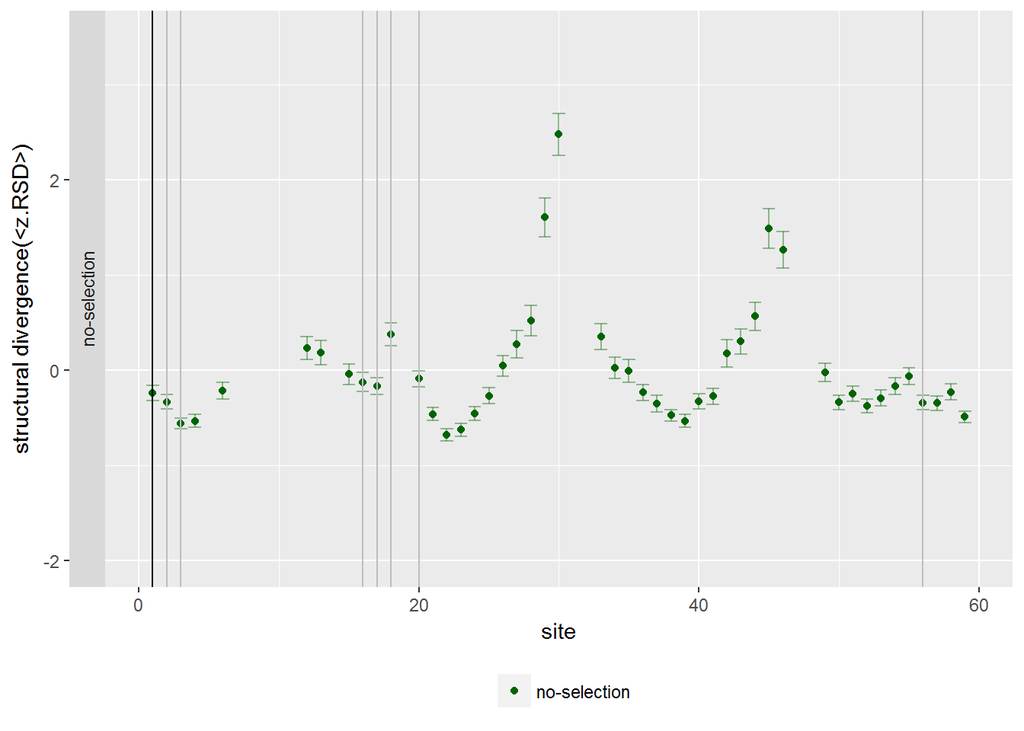

Black lines are the active sites and grey lines are their contacts

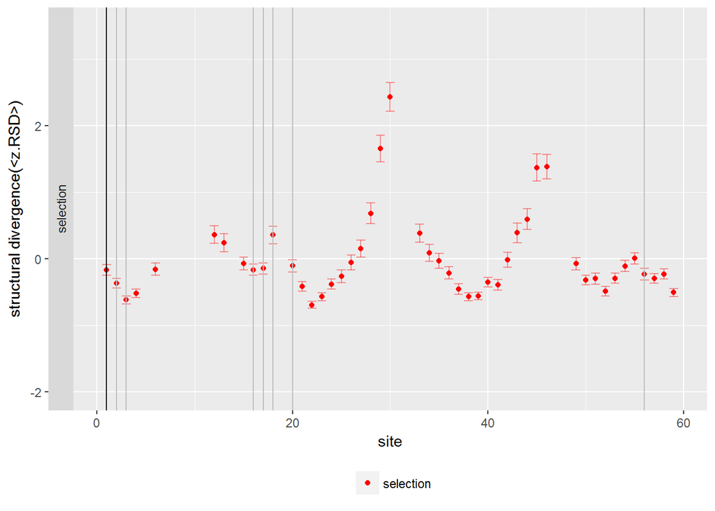

Black lines are the active sites and grey lines are their contacts

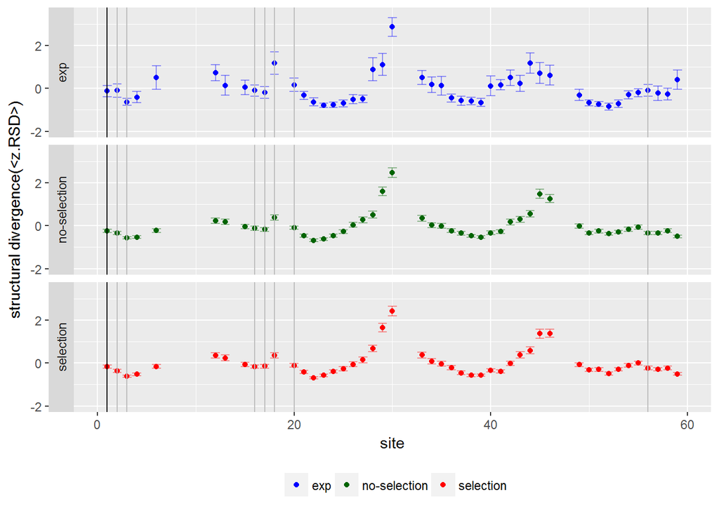

Black lines are the active sites and grey lines are their contacts

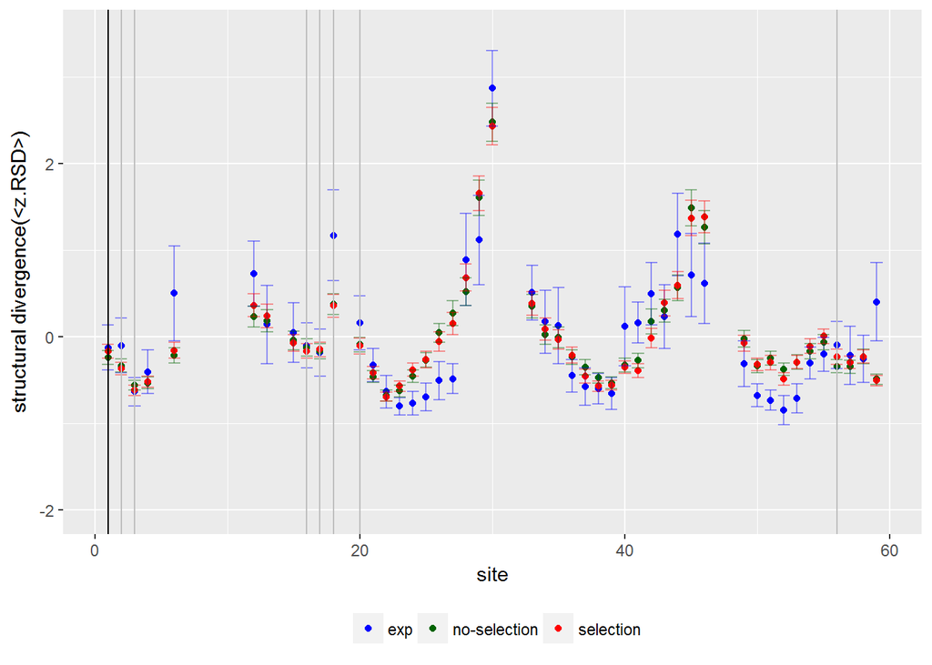

Black lines are the active sites and grey lines are their contacts

### Correlation between site profiles

Correlation between <z.RSD> profiles

| comparison | R |
| --- | --- |
| exp vs no-selection | 0.83 |
| exp vs selection | 0.84 |
| no-selection vs selection | 0.99 |

### Comparison between profiles

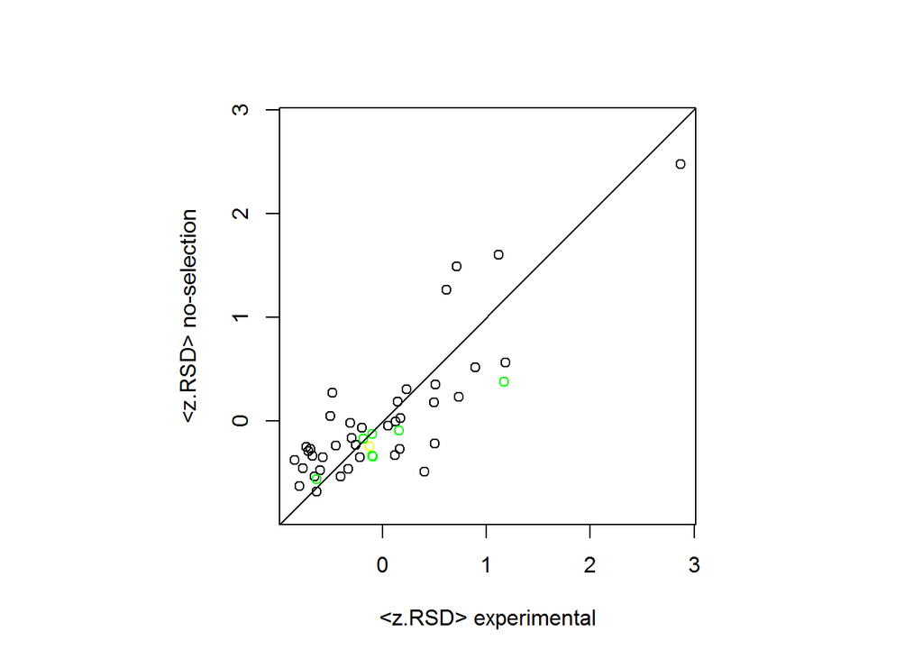

Yellow points are the active sites and green points are their contacts

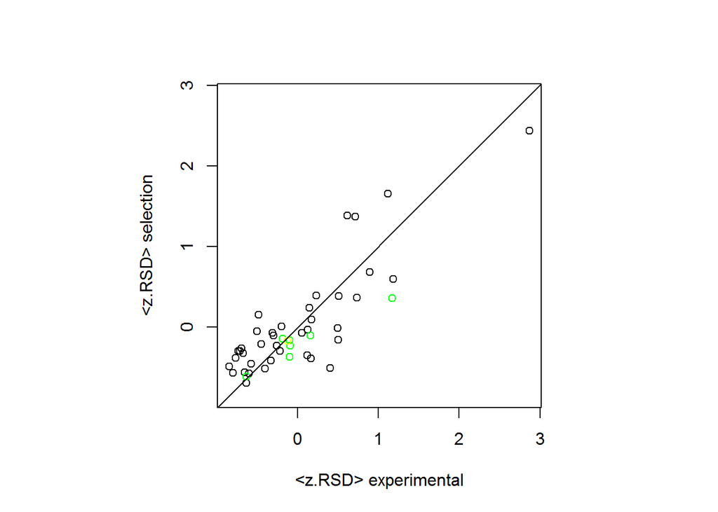

Yellow points are the active sites and green points are their contacts

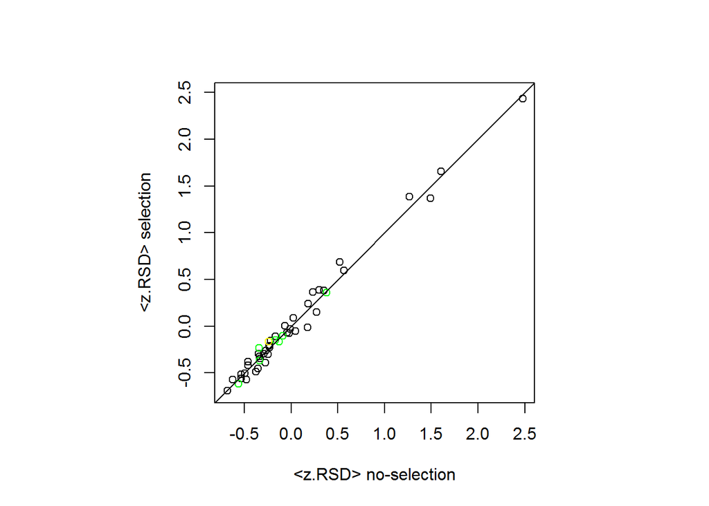

Yellow points are the active sites and green points are their contacts

### Distance to the active site

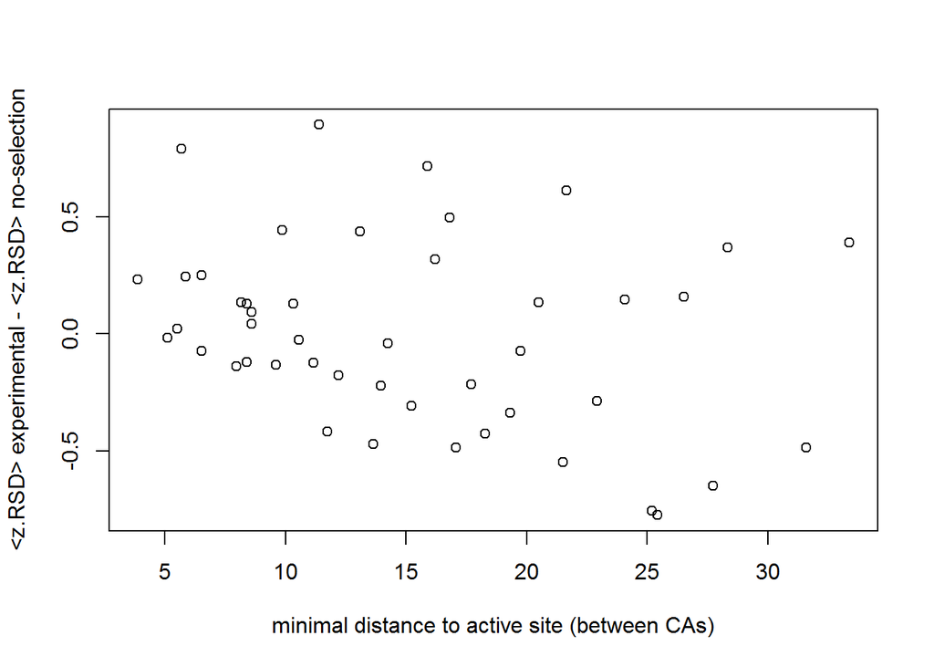

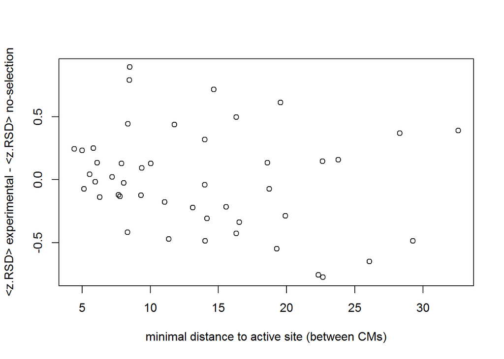

Correlation between differences in profiles and the minimal distance to the active site

| comparison | R |
| --- | --- |
| (<z.RSD> experimental - <z.RSD> no-selection) vs min.da.CA | -0.28 |
| (<z.RSD> experimental - <z.RSD> no-selection) vs min.da.CM | -0.22 |

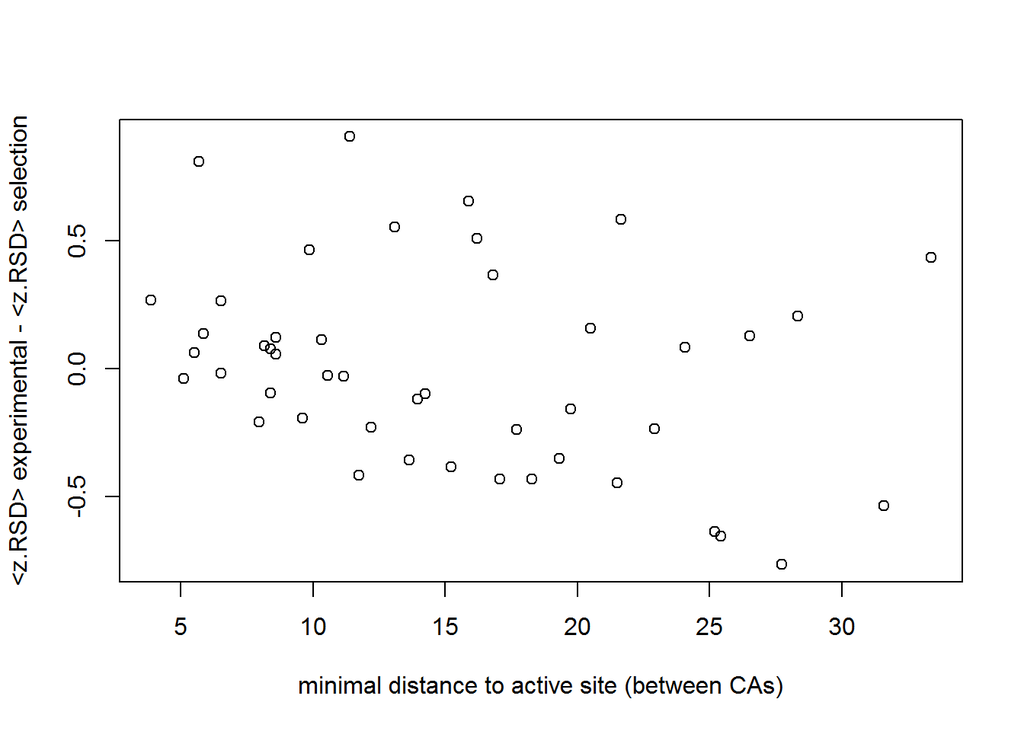

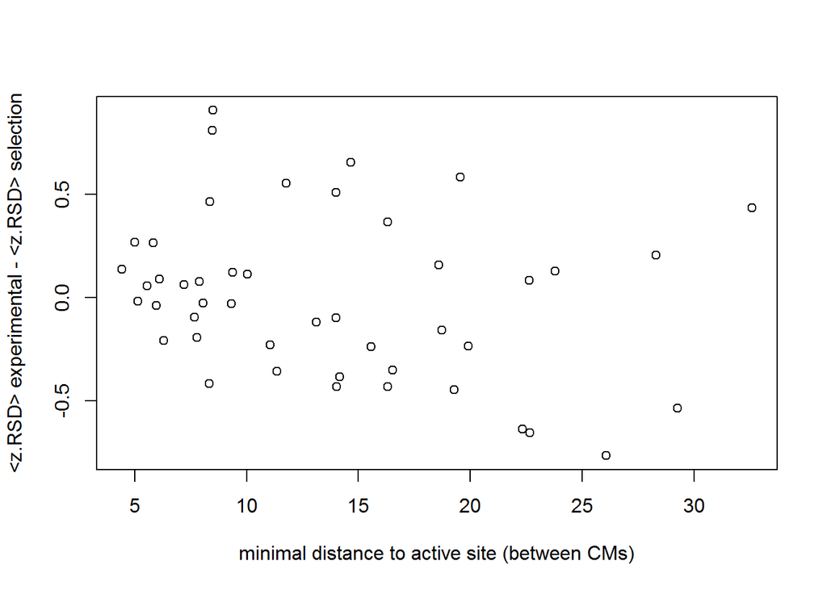

Correlation between differences in profiles and the minimal distance to the active site

| comparison | R |
| --- | --- |
| (<z.RSD> experimental - <z.RSD> selection) vs min.da.CA | -0.30 |
| (<z.RSD> experimental - <z.RSD> selection) vs min.da.CM | -0.24 |

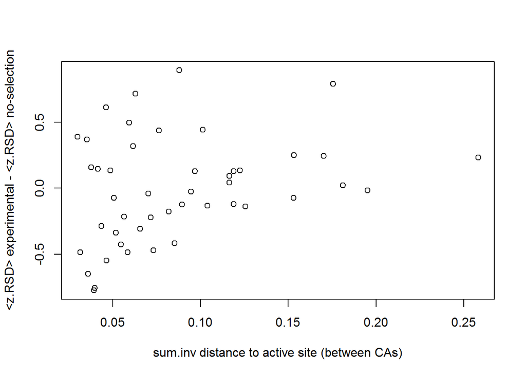

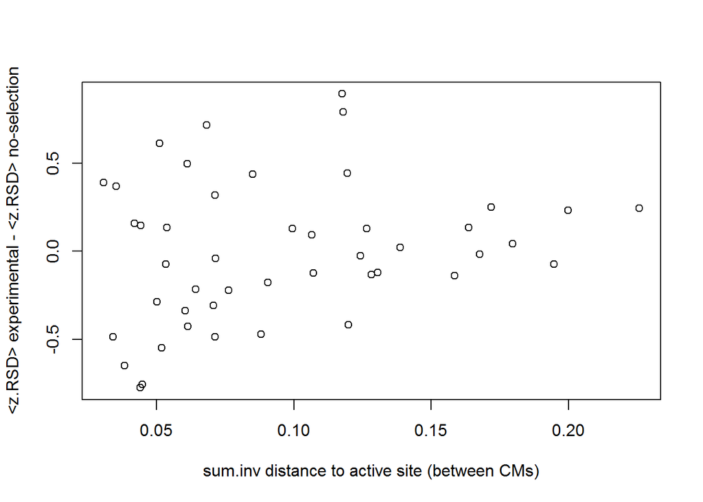

Correlation between differences in profiles and the sum.inv distance to the active site

| comparison | R |
| --- | --- |
| (<z.RSD> experimental - <z.RSD> no-selection) vs sum.inv.da.CA | 0.28 |
| (<z.RSD> experimental - <z.RSD> no-selection) vs sum.inv.da.CM | 0.23 |

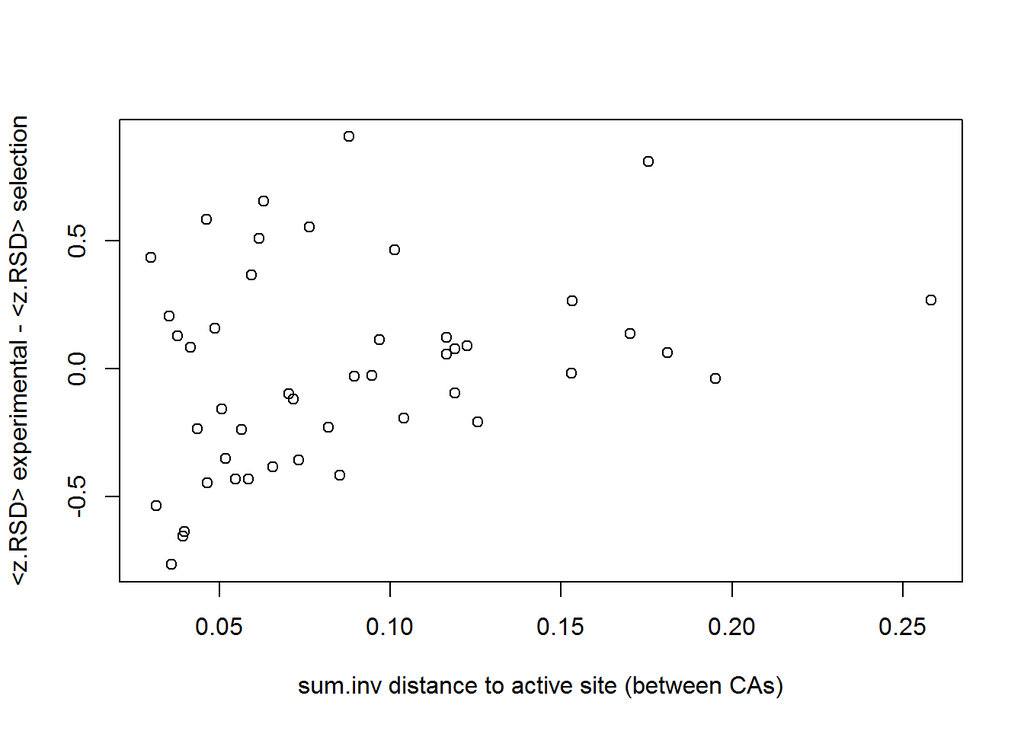

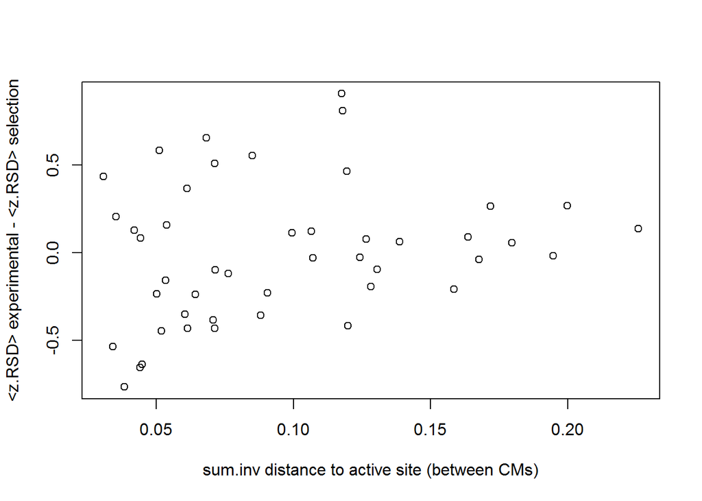

Correlation between differences in profiles and the sum.inv distance to the active site

| comparison | R |
| --- | --- |
| (<z.RSD> experimental - <z.RSD> selection) vs sum.inv.da.CA | 0.29 |
| (<z.RSD> experimental - <z.RSD> selection) vs sum.inv.da.CM | 0.23 |

Correlation between CN and the minimal distance to the active site

| comparison | R |
| --- | --- |
| CN vs min.da.CA | -0.54 |
| CN vs min.da.CM | -0.60 |

Correlation between CN and the sum.inv distance to the active site

| comparison | R |
| --- | --- |
| CN vs sum.inv.da.CA | 0.29 |
| CN vs sum.inv.da.CM | 0.46 |

### Sequence comparison

In this section we compare theoretical sequence divergence profiles with sequence scores obtained from ConsurfDB. To obtain theoretical profiles, for each selection regimen, we calculated the number of times we had mutated each site and divided this number by the number of times we had tried a mutation at the site.

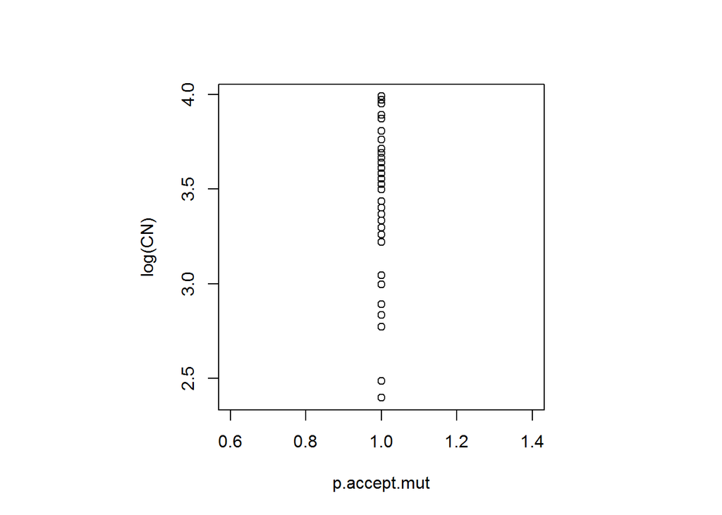

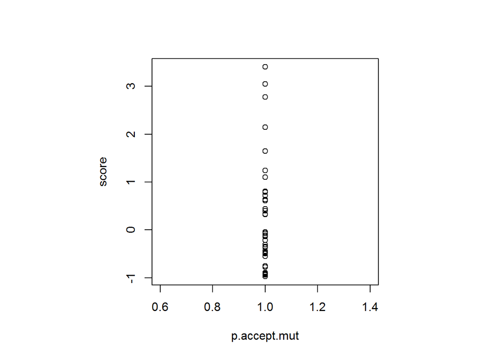

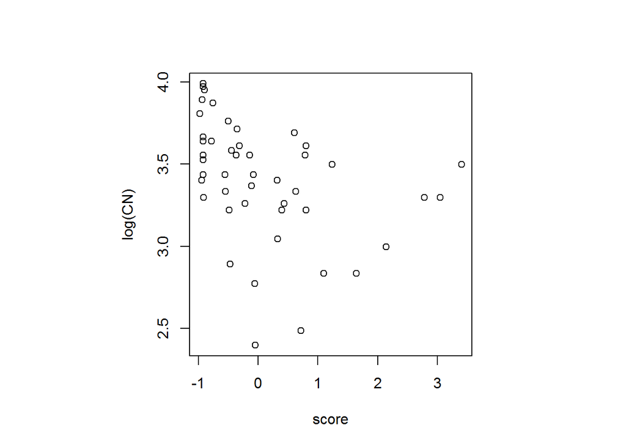

Correlation between sequence profiles

| comparison | R |
| --- | --- |
| paccept no-selection vs log(CN) | NA |
| paccept no-selection vs score | NA |
| score vs log(CN) | -0.39 |

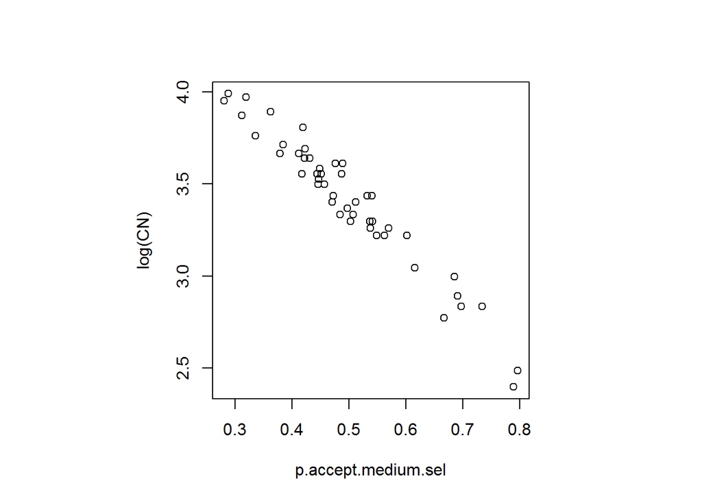

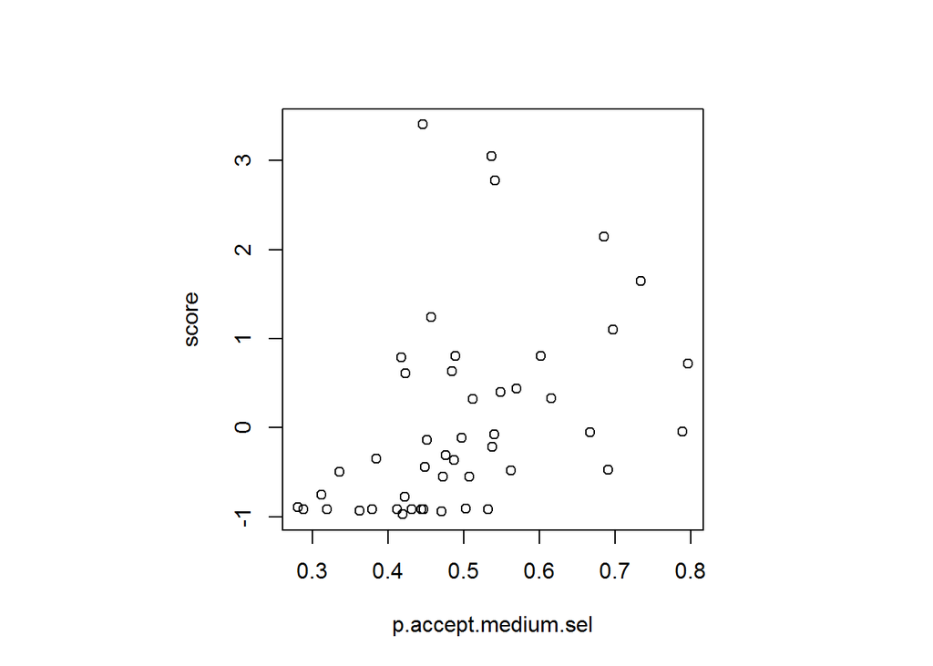

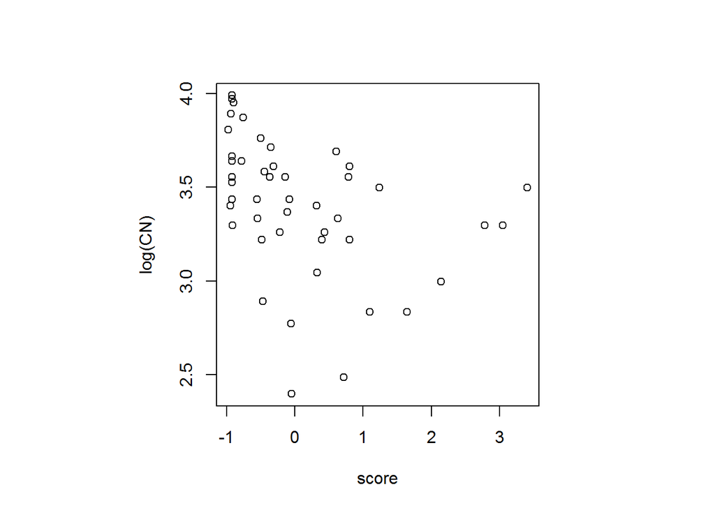

Correlation between sequence profiles

| comparison | R |
| --- | --- |
| paccept selection vs log(CN) | -0.97 |
| paccept selection vs score | 0.41 |
| score vs log(CN) | -0.39 |